# NBA: CV Y Regularizacion

Antonio Pascual Hernandez

# Cross Validation

## Validation Set

Consiste en dividir la muestra de forma aleatoria en dos submuestras.

Se han eliminado los NAs, los datos duplicados y las variables categoricas

```
## [1] 12272.61 12291.03
```

Creamos un modelo en el que el salario depende de todas las variables (regres_train). Creamos un modelo en el que el salario depende del nº de draft, de la edad, de los partidos jugados y de los minutos jugados (regres_train1) Como el mejor modelo será aque con un menor AIC, elegimos el modelo regres_train

```
## [1] 2.710411e+13 2.824005e+13
```

## Leave-One-Out Cross-Validation

El LOOCV consiste en tomar una muestra con todos los datos menos uno. Se estima el modelo y se predice sobre el dato que se ha dejado fuera. Este proceso se repite para los n datos.

```
##     (Intercept) NBA_DraftNumber             Age               G              MP
##    -2257548.579      -60665.040      517568.920     -154422.070        5670.113
##             PER             TS.           X3PAr             FTr            ORB.
##     -353477.554    -2184161.999    -3441403.308     -151799.733    -1067597.188
##            DRB.            TRB.            AST.            STL.            BLK.
##     -868491.151     2033598.230      -19939.415     -194111.775      110026.871
##            TOV.            USG.             OWS             DWS              WS
##        4105.603      167442.270    -1323604.522    -1790689.848     1877630.187
##           WS.48            OBPM            DBPM             BPM            VORP
##     1893689.180     1935687.128     1494921.908    -1353095.027      632084.891
```

```
## [1] 2.872590e+13 2.872079e+13
```

```
## [1] 2.872590e+13 2.872079e+13
```

El primer valor de delta es la estimación k-fold estándar y el segundo con el sesgo corregido.

## K-Fold Cross-Validation

Supone dividir la muestra en k grupos o folds, de aproximadamente igual tamaño. Cada folds es tratado como un conjunto de validación, de tal forma que se estima el modelo con los datos que no están el fold (los otros k−1 folds) y se predicen en el fold.

```
## [1] 2.966498e+13 2.931969e+13
```

```
## [1] 2.921033e+13 2.891670e+13
```

El primer valor de delta es la estimación k-fold estándar y el segundo con el sesgo corregido.

# Regularización

## Ridge

```
## [1] 339  24
```

La matriz tiene un dimesion de 339x24

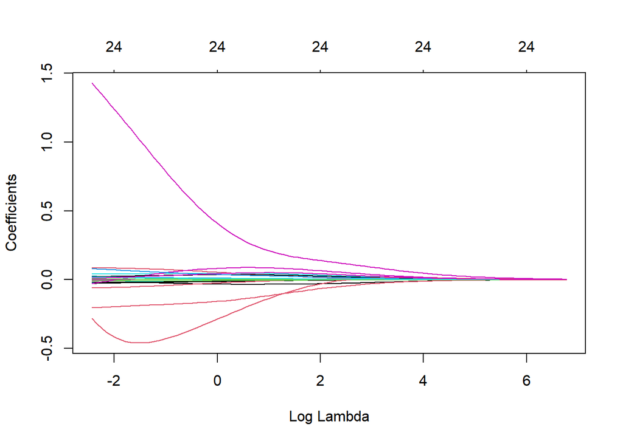

```
## [1] 875.2555 797.5003 726.6525 662.0987 603.2797 549.6860
```

```
##           MP            G
## 0.0005263866 0.0004060025
```

```
##         AST.           MP
## 3.377707e-38 1.087347e-39
```

## Tuning λ

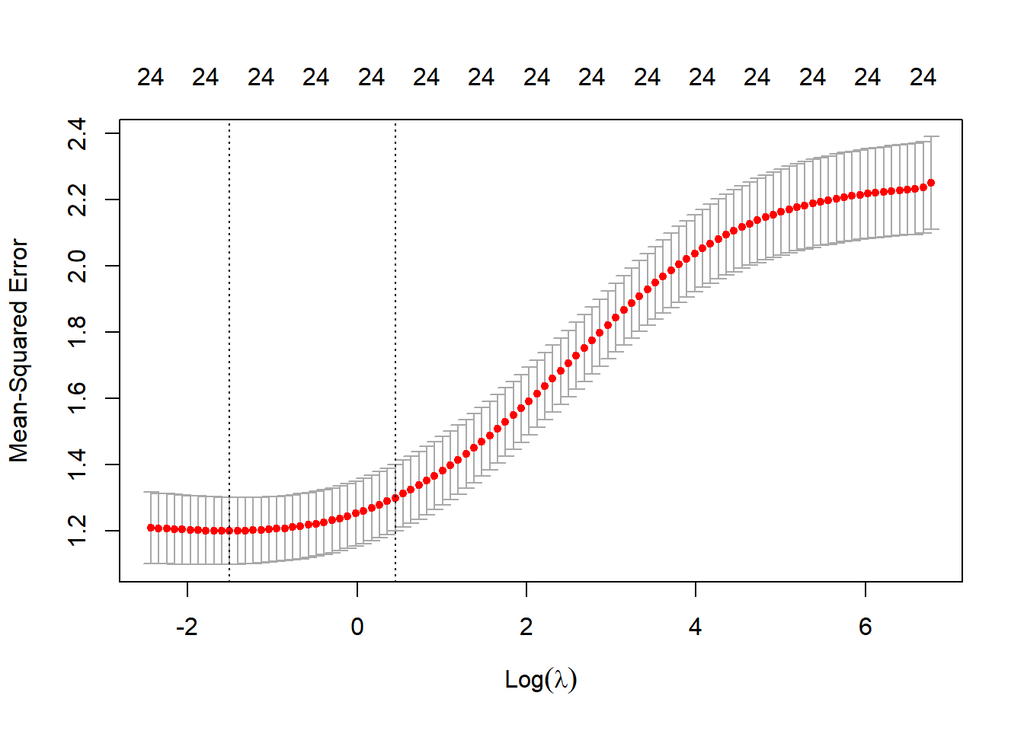

```
## [1] 1.199605
```

```
## [1] 0.2219092
```

```
## [1] -1.505487
```

```
## [1] 1.299326
```

```
## [1] 1.565525
```

```
## [1] 0.4482215
```

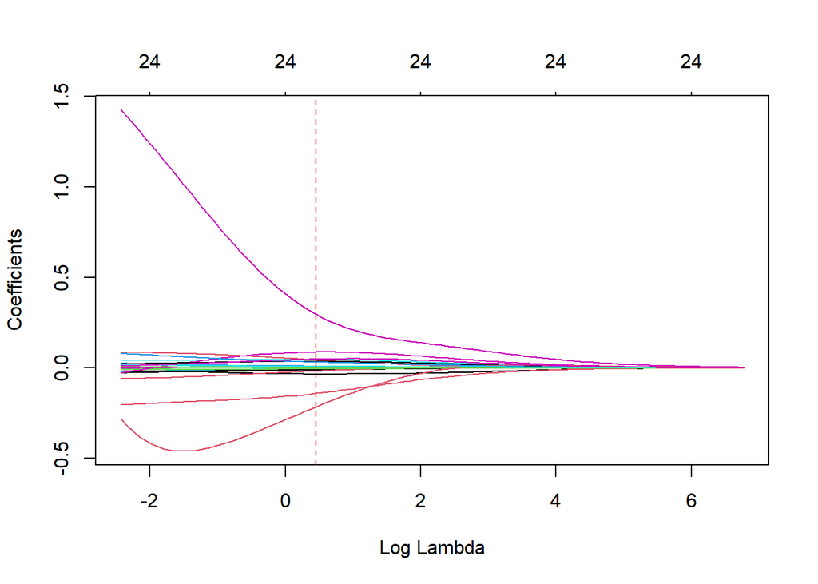

### Ventajas y desventajas

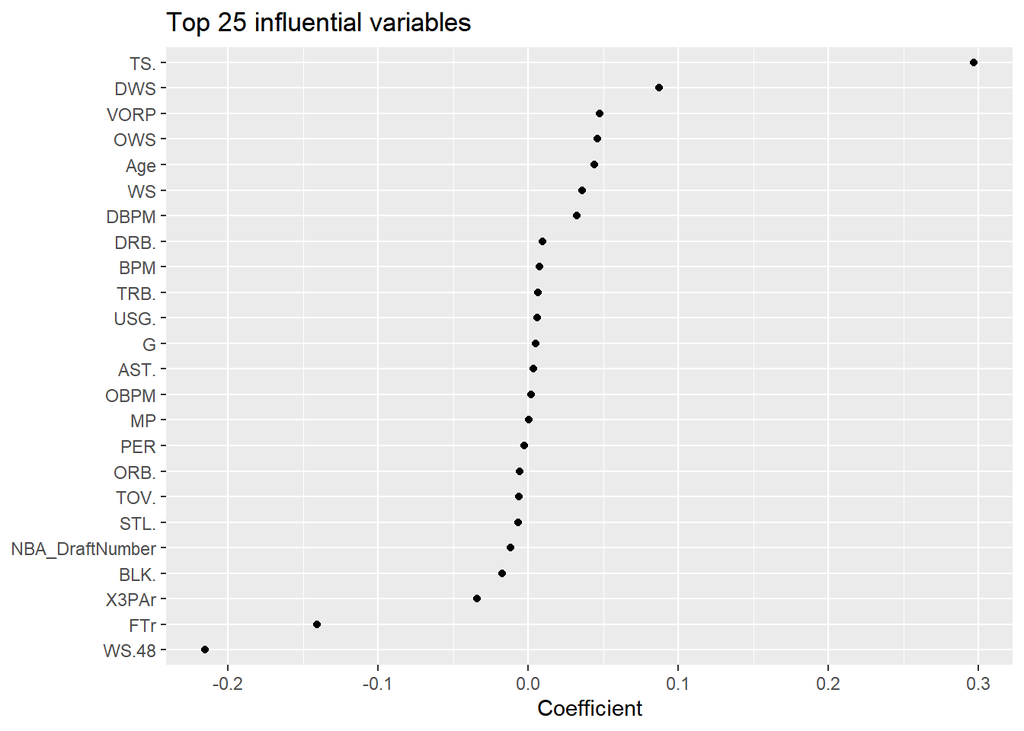

## Lasso

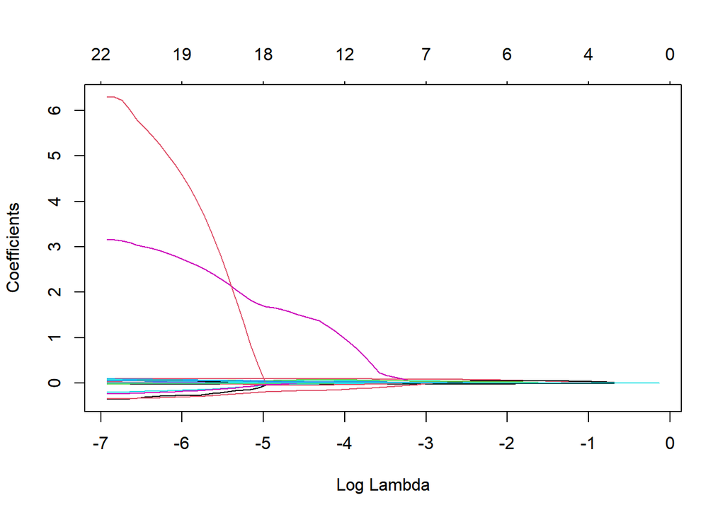

## Tuning - CV

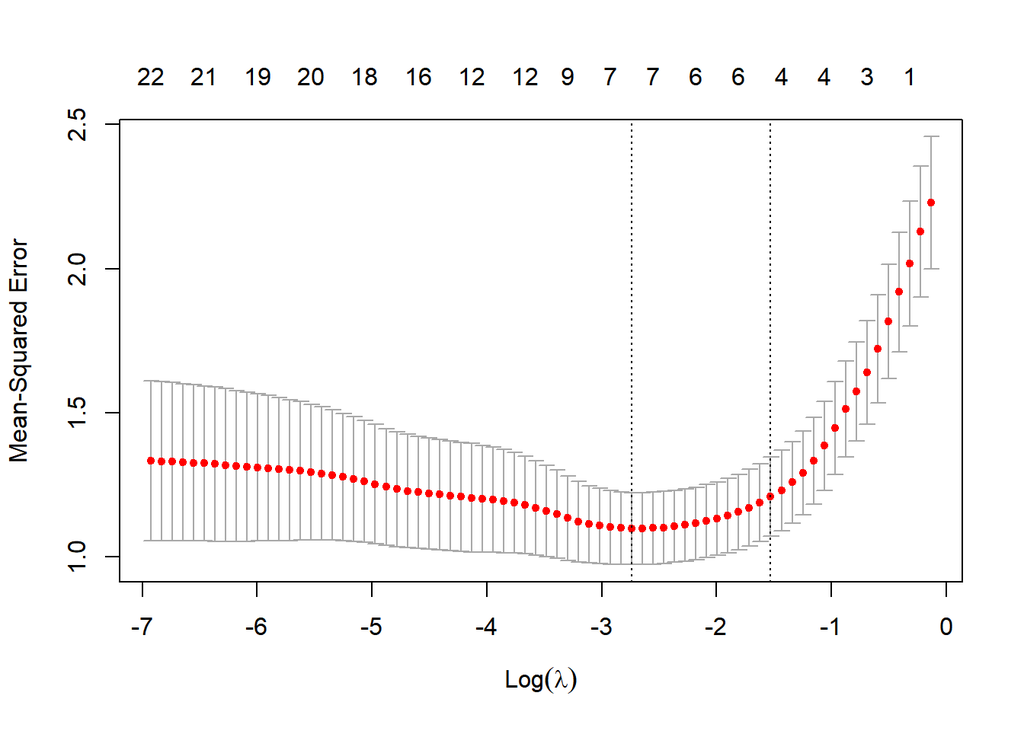

```
## [1] 1.098707
```

```
## [1] 0.0646877
```

```
## [1] 1.209217
```

```
## [1] 0.2168075
```

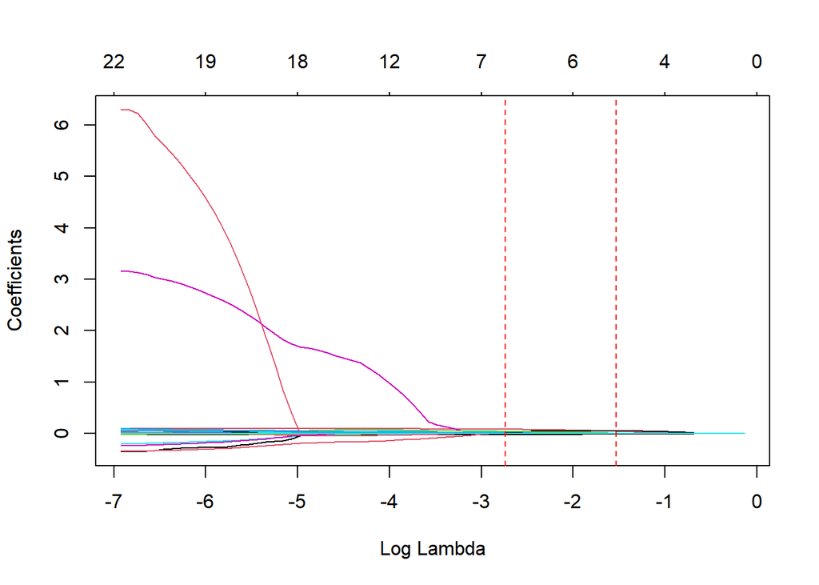

### Ventajas y Desventajas

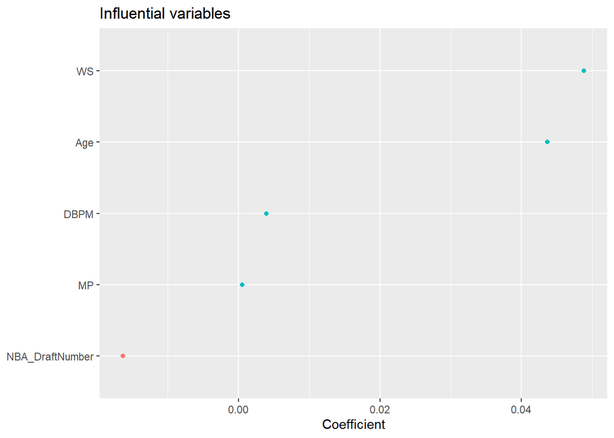

```
## [1] 1.199605
```

```
## [1] 1.098707
```

## Elastic Net (Red elástica)

La red elástica es otra penalización que incorpora la selección variable del lazo y la contracción de predictores correlacionados como la regresión de ridge.

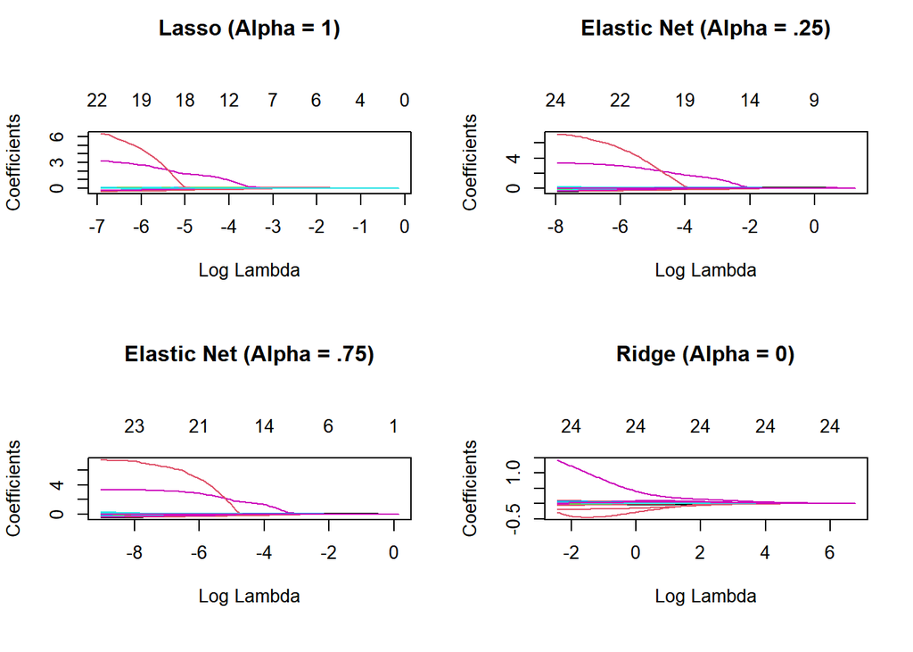

Se escoge el lasso.

## Tuning

Elastic nets: λ y α

```
## # A tibble: 11 x 5
##    alpha mse_min mse_1se lambda_min lambda_1se
##    <dbl> <lgl>   <lgl>   <lgl>      <lgl>
##  1   0   NA      NA      NA         NA
##  2   0.1 NA      NA      NA         NA
##  3   0.2 NA      NA      NA         NA
##  4   0.3 NA      NA      NA         NA
##  5   0.4 NA      NA      NA         NA
##  6   0.5 NA      NA      NA         NA
##  7   0.6 NA      NA      NA         NA
##  8   0.7 NA      NA      NA         NA
##  9   0.8 NA      NA      NA         NA
## 10   0.9 NA      NA      NA         NA
## 11   1   NA      NA      NA         NA
```

```
## # A tibble: 11 x 5
##    alpha mse_min mse_1se lambda_min lambda_1se
##    <dbl>   <dbl>   <dbl>      <dbl>      <dbl>
##  1   0      1.21    1.29     0.467       1.72
##  2   0.1    1.17    1.25     0.337       1.03
##  3   0.2    1.14    1.23     0.269       0.681
##  4   0.3    1.13    1.22     0.196       0.498
##  5   0.4    1.12    1.20     0.162       0.374
##  6   0.5    1.12    1.20     0.129       0.328
##  7   0.6    1.11    1.19     0.118       0.273
##  8   0.7    1.11    1.20     0.101       0.257
##  9   0.8    1.11    1.19     0.0887      0.225
## 10   0.9    1.11    1.18     0.0789      0.200
## 11   1      1.11    1.18     0.0710      0.180
```

Nos quedamos con alpha = 1, ya que su landa es el menor

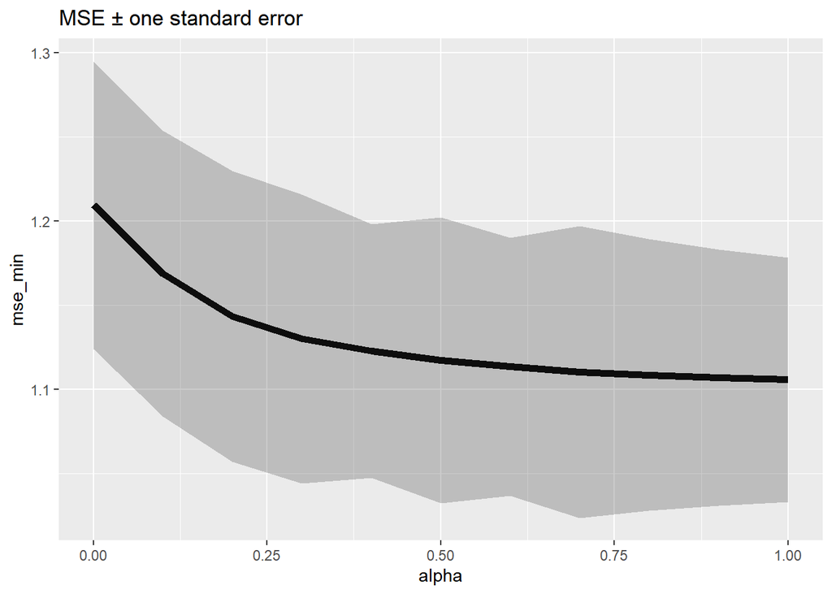